# LAD calibration

## UCLouvain

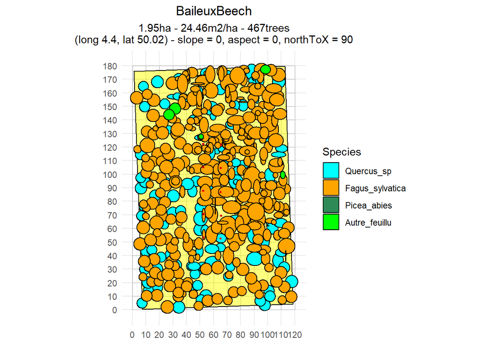

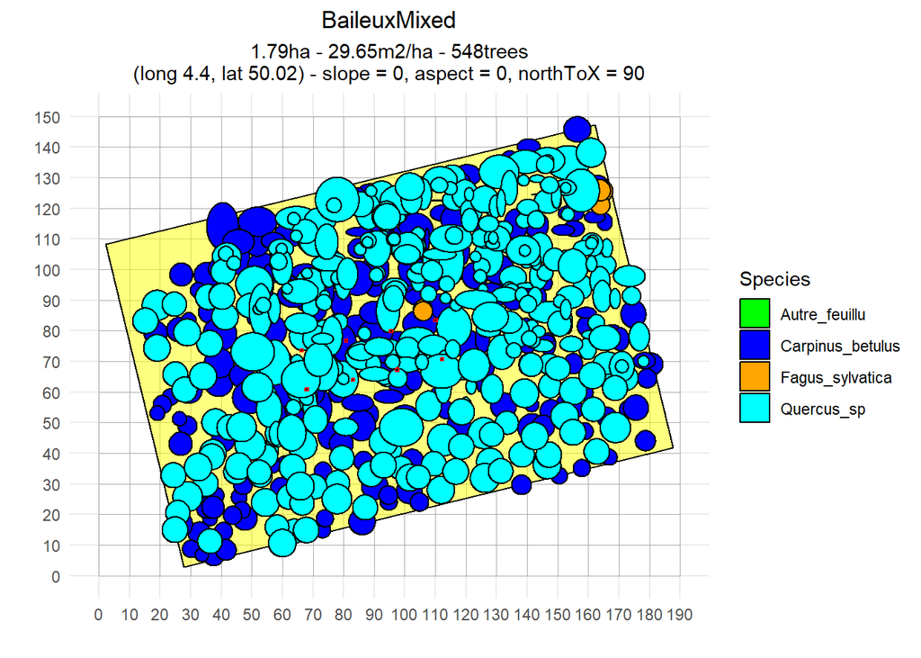

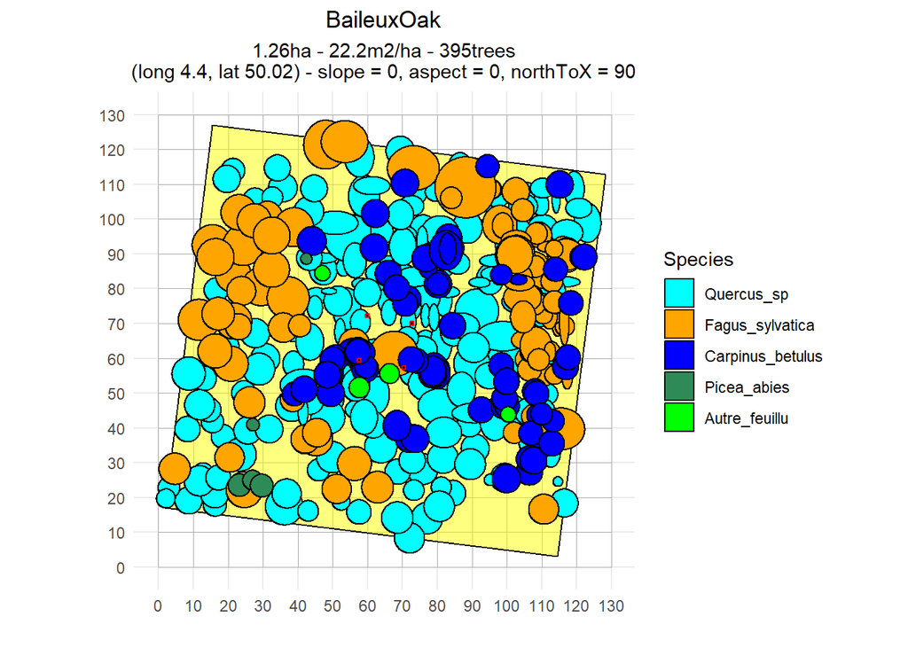

# First results

```
##   id_mod species_specific dbh_effect compet_effect
## 1      1             TRUE       TRUE          TRUE
```

We ran 60,000 samplings, with a burning period of 10,000 samplings. We got 3 chains containing each 16,668 saplings. We analyse the output by keeping the last 5,000 samplings of each chain.

The time was about:

```
## Time difference of 2.827242 hours
```

## Species effect

### Trace

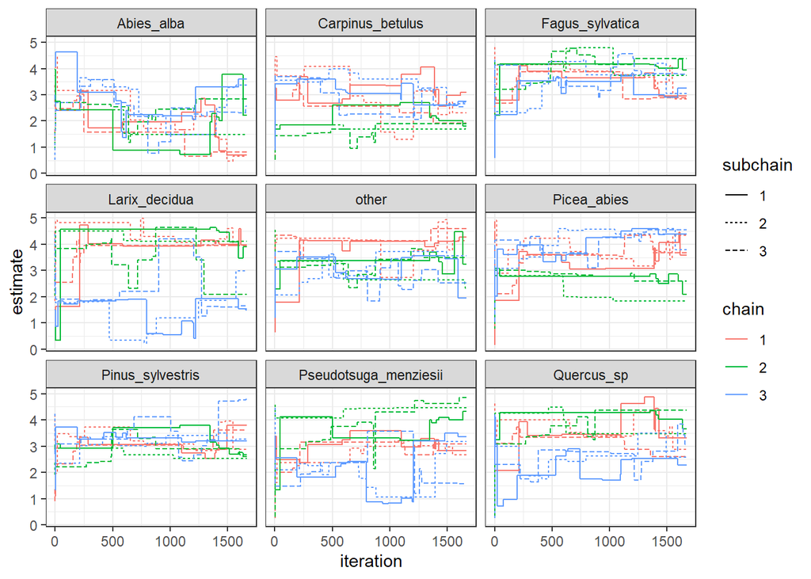

### Density

```
##                 species     lower   median    upper
## 1            Abies_alba 0.6513092 2.261323 3.777163
## 2      Carpinus_betulus 1.4396527 2.613910 4.074585
## 3      Pinus_sylvestris 2.3352888 3.062914 4.107518
## 4 Pseudotsuga_menziesii 1.0015834 3.073523 4.630049
## 5            Quercus_sp 1.7085994 3.393076 4.475713
## 6                 other 1.9587209 3.410949 4.605023
## 7           Picea_abies 1.8365903 3.516621 4.583914
## 8       Fagus_sylvatica 2.3556066 3.789376 4.764369
## 9         Larix_decidua 0.4376146 3.941758 4.829749
```

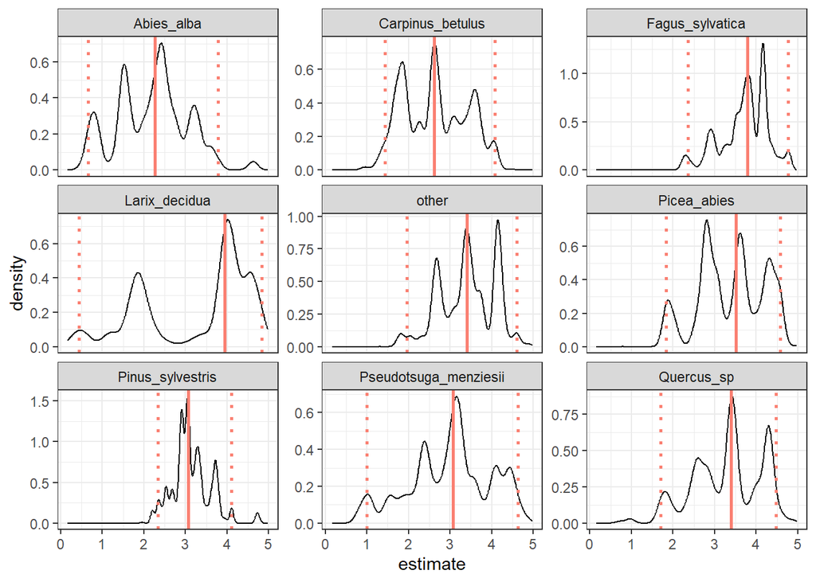

## DBH effect

### Trace

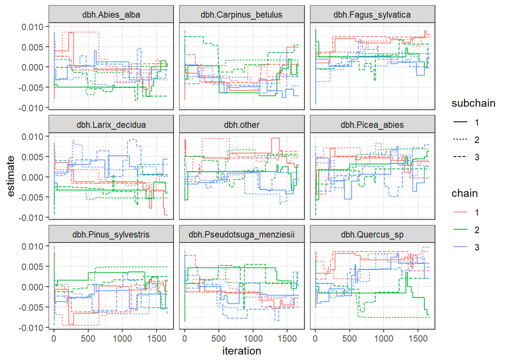

### Density

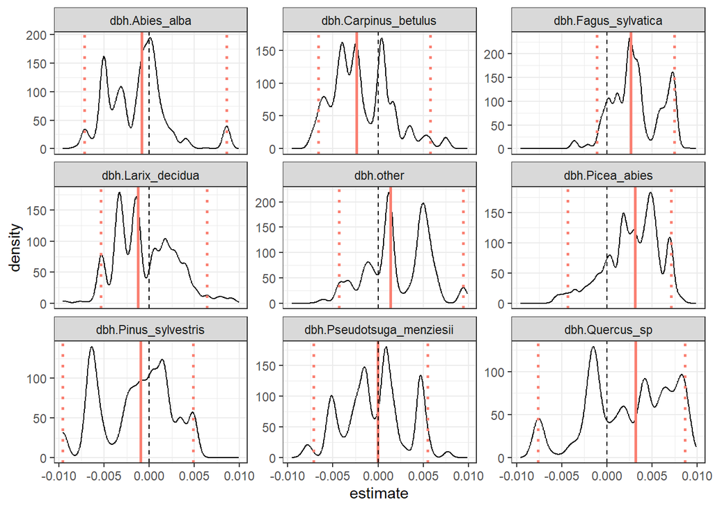

## Competition effect

### Trace

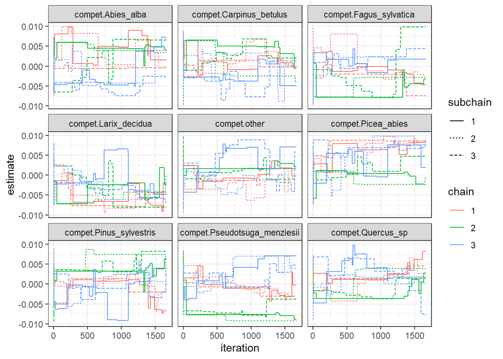

### Density

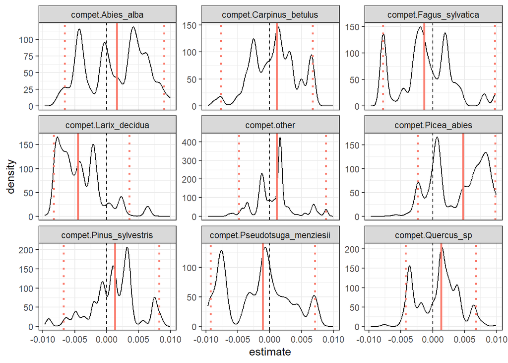

# Perspectives

There is still problem of convergence, we need to explore why.

Once we are satisfied with the modelling approach, we will study the ecological mechanisms that could underlie the differences between species. Do species with different shade tolerance have different leaf area densities? Do they react differently to competition? **Ecological assumptions still have to be made.**